# LogLogPlot

#### Description

Log-log plot, Plot a trend on log-log paper.

#### Usage

```
LogLogPlot(frame, xvar, yvar, title, ..., use_coord_trans = FALSE)
```

#### Arguments

- `frame`: data frame to get values from
- `xvar`: name of the independent (input or model) column in frame
- `yvar`: name of the dependent (output or result to be modeled) column in frame
- `title`: title to place on plot
- `...` : no unnamed argument, added to force named binding of later arguments.
- `use_coord_trans`: logical if TRUE, use coord_trans instead of coord_trans(x = “log10”, y = “log10”) instead of scale_x_log10() + scale_y_log10() (useful when there is not enough range to show ticks).

#### Examples

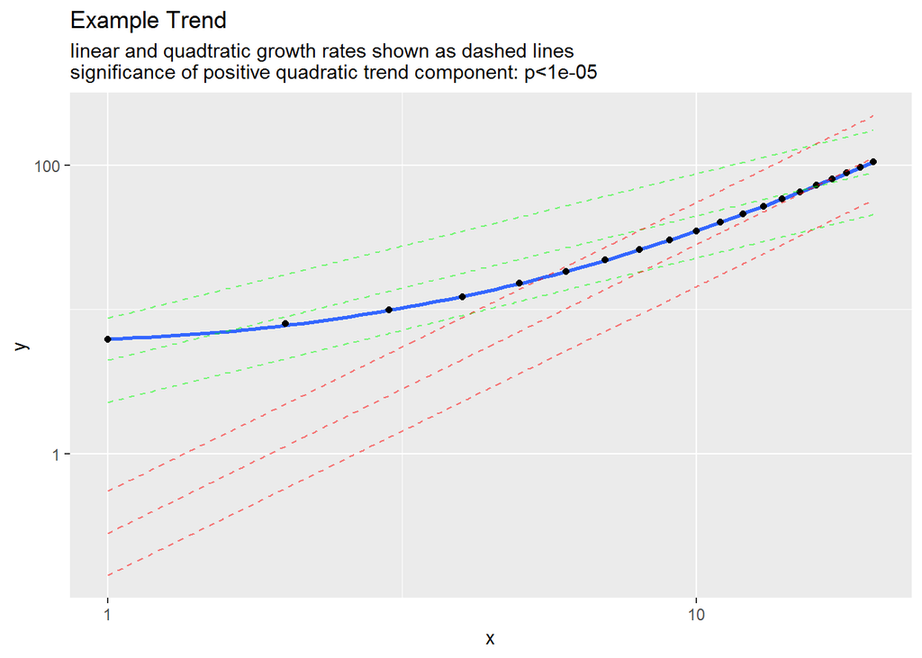

```r
set.seed(5326)
frm = data.frame(x = 1:20)
frm$y <- 5 + frm$x + 0.2 * frm$x * frm$x + 0.1*abs(rnorm(nrow(frm)))
WVPlots::LogLogPlot(frm, "x", "y", title="Example Trend")
```

#### Details

This plot is intended for plotting functions that are observed costs or durations as a function of problem size. In this case we expect the ideal or expected cost function to be non-decreasing. Any negative trends are assumed to arise from the noise model. The graph is specialized to compare non-decreasing linear and non-decreasing quadratic growth. Some care must be taken in drawing conclusions from log-log plots, as the transform is fairly violent. Please see: “(Mar’s Law) Everything is linear if plotted log-log with a fat magic marker” (from Akin’s Laws of Spacecraft Design http://spacecraft.ssl.umd.edu/akins_laws.html), and “So You Think You Have a Power Law” http://bactra.org/weblog/491.html.